# Untitled

MP Etienne

2022-11-29 (updated: 2023-01-11)

name: ancova # Comparaison de droite de régression : modèle d’analyse de la covariance

## Cadre général C’est la situation où * la variable à expliquer $Y$ est quantitative * Les variables explicatives sont qualitatives et quantitatives

`` ## `geom_smooth()` using formula 'y ~ x' ``

`## Warning: Removed 2 rows containing non-finite values (stat_smooth).`

`## Warning: Removed 2 rows containing missing values (geom_point).`

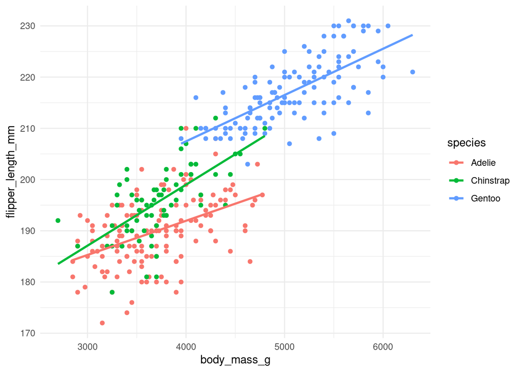

template: ancova ## Le modèle

$$M_{comp} : \class{alea}{Y_{ik}} = \class{rouge}{\mu} + \class{rouge}{\alpha_i} + \class{rouge}{\beta}x_{ik} +\class{rouge}{\gamma_i} x_{ik} + \class{alea}{E_{ik}},\quad \class{alea}{E_{ik}}\overset{ind}{\sim}\mathcal{N}(0, \class{rouge}{\sigma^2}),$$
avec - $i=1,\ldots,I$ le niveau du facteur 1, - $x_{ik}$ la mesure de la variable quantitative $x$ sur l’individu $k$ du groupe $i$, - $\class{rouge}{\mu}$ l’ordonnée à l’origine de référence, - $\class{rouge}{\alpha_i}$ l’effet différentiel de l’espèce $i$ sur l’ordonnée à l’origine, ( $\alpha_1=0$ ) - $\class{rouge}{\beta}$ l’effet de la variable $x$ pour le groupe de référence,
- $\class{rouge}{\gamma_i}$ l’effet différentiel de la variable $x$ pour le groupe $i$ par rapport au groupe de référence ( $\gamma_1=0$ ),
- $\class{rouge}{\sigma^2}$ la variance commune à tous les groupes.

### Nombre de paramètres du modèle

- $2I$ paramètres de moyenne $(\class{rouge}{(\mu, \alpha_2, \ldots, \alpha_I, \beta, \gamma_2, \ldots, \gamma_I)}$;
- 1 paramètre de variance $\class{rouge}{\sigma^2}$

| name: test_complet |
| --- |
| # Tests dans le modèle d’analyse de la covariance |

## Test du modèle complet

Pour répondre à la question “La longueur des ailes des manchots est elle liée à leur masse et/ou à leur espèce ?”

$$\begin{align}
H_0 & =\left \lbrace \mbox{La longueur des ailes est la même en moyenne quelque soit la masse ou l'espèce du manchot }\right\rbrace\\
& =\left \lbrace \mbox{pour tout }i, \alpha_i =0, \gamma_i = 0 \mbox{ et }\beta=0 \right\rbrace\\
& =\left \lbrace M_{comp} \mbox{ est équivalent à } M0 \right\rbrace.
\end{align}$$

$H_1$ prend les formes équivalentes suivantes

$$\begin{align}
H_1 & =\left \lbrace \mbox{la longueur des ailes varie selon la masse ou l'espèce }\right\rbrace\\
& =\left \lbrace \mbox{Il existe un }i, \alpha_i \ne 0 \mbox{ ou un } \gamma_i \ne 0 \mbox{ ou } \beta \ne 0 \right\rbrace\\
& =\left \lbrace M_{comp} \mbox{ est préférable à } M0 \right\rbrace.
\end{align}$$
— template: test_complet

## $$F = \frac{\frac{RSS_0-RSS}{2I-1}}{\frac{RSS}{n-2I}} \underset{H_0}{\sim} \mathcal{F}(2I-1, n-2I)$$

template: test_complet

## Test du modèle complet sur l’exemple manchot

```r
Mcomp <- lm(flipper_length_mm ~ species + body_mass_g + species:body_mass_g, data =penguins)
M0 <- lm(flipper_length_mm ~ 1, data =penguins)
anova(M0, Mcomp)
```

```
## Analysis of Variance Table
##
## Model 1: flipper_length_mm ~ 1
## Model 2: flipper_length_mm ~ species + body_mass_g + species:body_mass_g
##   Res.Df   RSS Df Sum of Sq      F    Pr(>F)
## 1    341 67427
## 2    336  9611  5     57815 404.24 < 2.2e-16 ***
## ---
## Signif. codes:  0 '***' 0.001 '**' 0.01 '*' 0.05 '.' 0.1 ' ' 1
```

| template: test_complet |
| --- |
| ## Test de l’égalité des pentes |

$$\begin{align}
H_0 & =\left \lbrace \mbox{La longueur des ailes augmente de la même manière avec le poids quelque soit l'espèce }\right\rbrace\\
& =\left \lbrace \mbox{pour tout }i, \gamma_i = 0 \right\rbrace\\
& =\left \lbrace M_{comp} \mbox{ est équivalent à } M_{12} \right\rbrace.
\end{align}$$

## $$M_{12} : \class{alea}{Y_{ik}} = \class{rouge}{\mu} + \class{rouge}{\alpha_i} + \class{rouge}{\beta}x_{ik} + \class{alea}{E_{ik}},\quad \class{alea}{E_{ik}}\overset{ind}{\sim}\mathcal{N}(0, \class{rouge}{\sigma^2})$$

$$\begin{align}
H_1 & =\left \lbrace \mbox{L'augmentation de longueur des ailes avec le poids n'est pas la même pour toutes les espèces}\right\rbrace\\
& =\left \lbrace \mbox{Il existe un }i,\gamma_i \ne 0 \right\rbrace\\
& =\left \lbrace M_{comp} \mbox{ est préférable à } M_{12} \right\rbrace.
\end{align}$$

| template: test_complet |
| --- |
| ## Test de l’égalité des pentes |
| ### Statistique de test |

$$F = \frac{\frac{RSS_{12}-RSS}{I-1}}
{\frac{RSS}{n-2I}} \underset{H_0}{\sim} \mathcal{F}(I-1, n-2I)$$

[output not shown]

template: test_complet

## Test de l’égalité des pentes sur l’exemple manchots

```r
M12 <- lm(flipper_length_mm ~ species + body_mass_g, data =penguins)
anova(M12, Mcomp)
```

```
## Analysis of Variance Table
##
## Model 1: flipper_length_mm ~ species + body_mass_g
## Model 2: flipper_length_mm ~ species + body_mass_g + species:body_mass_g
##   Res.Df    RSS Df Sum of Sq      F Pr(>F)
## 1    338 9839.1
## 2    336 9611.2  2    227.91 3.9837 0.0195 *
## ---
## Signif. codes:  0 '***' 0.001 '**' 0.01 '*' 0.05 '.' 0.1 ' ' 1
```

[output not shown]

name: ajuste

# Comparer les espèces à poids équivalents

La répondre à la question “Les longueurs des ailes des manchots des différentes espèces sont-elles comparables”

Pour rendre la comparaison juste, il faut choisir un poids de référence.

–

Moyenne ajustée

$$\hat{\mu}_i = \mu + \alpha_i + (\beta+\gamma_i) \bar{x}$$

–

```r
library(emmeans)
mean_length <- emmeans(object = Mcomp, specs = ~ species)
```

```
## NOTE: Results may be misleading due to involvement in interactions
```

```r
pairs(mean_length, adjust = "bonf")
```

```
##  contrast           estimate   SE  df t.ratio p.value
##  Adelie - Chinstrap    -8.10 1.21 336  -6.678  <.0001
##  Adelie - Gentoo      -15.99 1.16 336 -13.733  <.0001
##  Chinstrap - Gentoo    -7.88 1.41 336  -5.582  <.0001
##
## P value adjustment: bonferroni method for 3 tests
```

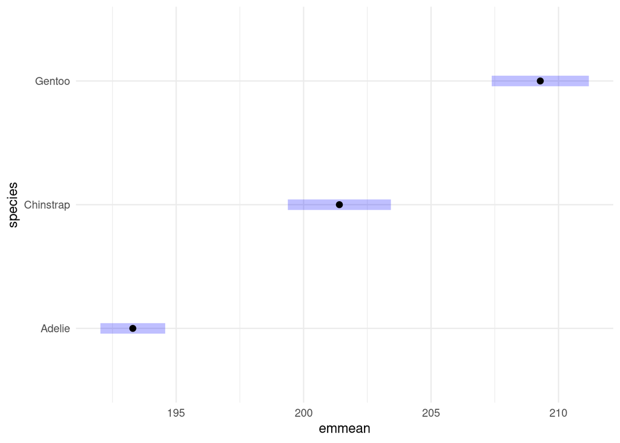

```r
plot(mean_length)
```